# Análise Pokémon

A. Schmidt

June 1, 2019

# Introdução

Este documento tem as análises do banco de dados [Pokémon](https://github.com/ayoubimaya/pokemon).

## Leitura dos dados

Vamos buscar os dados de duas fontes: [Fonte 1](https://tinyurl.com/pokemon-rladies-01) e [Fonte 2](https://tinyurl.com/pokemon-rladies-02).

```r
Pokemon_01 <- read.csv('https://tinyurl.com/pokemon-rladies-01')
Pokemon_02 <- read.csv('https://tinyurl.com/pokemon-rladies-02')

head(Pokemon_01, n=10)
```

```
##    ID                      Nome Tipo1  Tipo2 Geracao Lendario
## 1   1                 Bulbasaur Grass Poison       1    FALSE
## 2   2                   Ivysaur Grass Poison       1    FALSE
## 3   3                  Venusaur Grass Poison       1    FALSE
## 4   3     VenusaurMega Venusaur Grass Poison       1    FALSE
## 5   4                Charmander  Fire              1    FALSE
## 6   5                Charmeleon  Fire              1    FALSE
## 7   6                 Charizard  Fire Flying       1    FALSE
## 8   6 CharizardMega Charizard X  Fire Dragon       1    FALSE
## 9   6 CharizardMega Charizard Y  Fire Flying       1    FALSE
## 10  7                  Squirtle Water              1    FALSE
```

```r
head(Pokemon_02, n = 3)
```

```
##   ID      Nome Total Vida Ataque Defesa AtaqueEsp DefesaEsp Velocidade
## 1  1 Bulbasaur   318   45     49     49        65        65         45
## 2  2   Ivysaur   405   60     62     63        80        80         60
## 3  3  Venusaur   525   80     82     83       100       100         80
```

```r
class(Pokemon_01)
```

```
## [1] "data.frame"
```

```r
class(Pokemon_02)
```

```
## [1] "data.frame"
```

```r
summary(Pokemon_01)
```

```
##        ID                             Nome         Tipo1
##  Min.   :  1.0   Abomasnow              :  1   Water  :112
##  1st Qu.:184.8   AbomasnowMega Abomasnow:  1   Normal : 98
##  Median :364.5   Abra                   :  1   Grass  : 70
##  Mean   :362.8   Absol                  :  1   Bug    : 69
##  3rd Qu.:539.2   AbsolMega Absol        :  1   Psychic: 57
##  Max.   :721.0   Accelgor               :  1   Fire   : 52
##                  (Other)                :794   (Other):342
##       Tipo2        Geracao       Lendario
##          :386   Min.   :1.000   Mode :logical
##  Flying  : 97   1st Qu.:2.000   FALSE:735
##  Ground  : 35   Median :3.000   TRUE :65
##  Poison  : 34   Mean   :3.324
##  Psychic : 33   3rd Qu.:5.000
##  Fighting: 26   Max.   :6.000
##  (Other) :189
```

```r
summary(Pokemon_02)
```

```
##        ID                             Nome         Total
##  Min.   :  1.0   Abomasnow              :  1   Min.   :180.0
##  1st Qu.:184.8   AbomasnowMega Abomasnow:  1   1st Qu.:330.0
##  Median :364.5   Abra                   :  1   Median :450.0
##  Mean   :362.8   Absol                  :  1   Mean   :435.1
##  3rd Qu.:539.2   AbsolMega Absol        :  1   3rd Qu.:515.0
##  Max.   :721.0   Accelgor               :  1   Max.   :780.0
##                  (Other)                :794
##       Vida            Ataque        Defesa         AtaqueEsp
##  Min.   :  1.00   Min.   :  5   Min.   :  5.00   Min.   : 10.00
##  1st Qu.: 50.00   1st Qu.: 55   1st Qu.: 50.00   1st Qu.: 49.75
##  Median : 65.00   Median : 75   Median : 70.00   Median : 65.00
##  Mean   : 69.26   Mean   : 79   Mean   : 73.84   Mean   : 72.82
##  3rd Qu.: 80.00   3rd Qu.:100   3rd Qu.: 90.00   3rd Qu.: 95.00
##  Max.   :255.00   Max.   :190   Max.   :230.00   Max.   :194.00
##
##    DefesaEsp       Velocidade
##  Min.   : 20.0   Min.   :  5.00
##  1st Qu.: 50.0   1st Qu.: 45.00
##  Median : 70.0   Median : 65.00
##  Mean   : 71.9   Mean   : 68.28
##  3rd Qu.: 90.0   3rd Qu.: 90.00
##  Max.   :230.0   Max.   :180.00
##
```

## Juntando os data frames

Vamos utilizar a função `merge()`.

```r
Pokemon <- merge(Pokemon_01, Pokemon_02, by = "ID")
head(Pokemon[, -7])
```

```
##   ID                Nome.x Tipo1  Tipo2 Geracao Lendario Total Vida Ataque
## 1  1             Bulbasaur Grass Poison       1    FALSE   318   45     49
## 2  2               Ivysaur Grass Poison       1    FALSE   405   60     62
## 3  3              Venusaur Grass Poison       1    FALSE   525   80     82
## 4  3              Venusaur Grass Poison       1    FALSE   625   80    100
## 5  3 VenusaurMega Venusaur Grass Poison       1    FALSE   525   80     82
## 6  3 VenusaurMega Venusaur Grass Poison       1    FALSE   625   80    100
##   Defesa AtaqueEsp DefesaEsp Velocidade
## 1     49        65        65         45
## 2     63        80        80         60
## 3     83       100       100         80
## 4    123       122       120         80
## 5     83       100       100         80
## 6    123       122       120         80
```

```r
Pokemon <- Pokemon[, -7]
head(Pokemon)
```

```
##   ID                Nome.x Tipo1  Tipo2 Geracao Lendario Total Vida Ataque
## 1  1             Bulbasaur Grass Poison       1    FALSE   318   45     49
## 2  2               Ivysaur Grass Poison       1    FALSE   405   60     62
## 3  3              Venusaur Grass Poison       1    FALSE   525   80     82
## 4  3              Venusaur Grass Poison       1    FALSE   625   80    100
## 5  3 VenusaurMega Venusaur Grass Poison       1    FALSE   525   80     82
## 6  3 VenusaurMega Venusaur Grass Poison       1    FALSE   625   80    100
##   Defesa AtaqueEsp DefesaEsp Velocidade
## 1     49        65        65         45
## 2     63        80        80         60
## 3     83       100       100         80
## 4    123       122       120         80
## 5     83       100       100         80
## 6    123       122       120         80
```

```r
names(Pokemon)[2] <- "Nome"
head(Pokemon)
```

```
##   ID                  Nome Tipo1  Tipo2 Geracao Lendario Total Vida Ataque
## 1  1             Bulbasaur Grass Poison       1    FALSE   318   45     49
## 2  2               Ivysaur Grass Poison       1    FALSE   405   60     62
## 3  3              Venusaur Grass Poison       1    FALSE   525   80     82
## 4  3              Venusaur Grass Poison       1    FALSE   625   80    100
## 5  3 VenusaurMega Venusaur Grass Poison       1    FALSE   525   80     82
## 6  3 VenusaurMega Venusaur Grass Poison       1    FALSE   625   80    100
##   Defesa AtaqueEsp DefesaEsp Velocidade
## 1     49        65        65         45
## 2     63        80        80         60
## 3     83       100       100         80
## 4    123       122       120         80
## 5     83       100       100         80
## 6    123       122       120         80
```

## Fazendo tabelas

Muitas vezes queremos olhar nossos dados em tabelas, para fazer cruzamentos dos nossos dados. Existem muitos pacotes para fazer tabelas “bonitas”, como o Kaggle e Stargazer (que é compatível com Latex). Alguns recursos disponíveis são:

- https://www.r-statistics.com/2013/07/tailor-your-tables-with-stargazer-new-features-for-latex-and-text-output/
- https://rmarkdown.rstudio.com/lesson-7.html
- https://cran.r-project.org/web/packages/kableExtra/vignettes/awesome_table_in_html.html
- https://bookdown.org/yihui/rmarkdown/tufte-tables.html

Também podemos usar nosso bom e velho pacote base para começar a manipular os dados.

```r
table(Pokemon$Tipo1, Pokemon$Lendario)
```

```
##
##            FALSE TRUE
##   Bug         83    0
##   Dark        35    2
##   Dragon      26   24
##   Electric    74    6
##   Fairy       16    1
##   Fighting    31    0
##   Fire        59    5
##   Flying       2    4
##   Ghost       58    4
##   Grass       73    5
##   Ground      28    8
##   Ice         24    2
##   Normal     106    2
##   Poison      28    0
##   Psychic     51   34
##   Rock        44    6
##   Steel       33    4
##   Water      120    6
```

Podemos também criar tabelas de frequências, da sequinte forma:

```r
Tabela <- table(Pokemon$Tipo1, Pokemon$Lendario)
round(prop.table(Tabela, 2),2)
```

```
##
##            FALSE TRUE
##   Bug       0.09 0.00
##   Dark      0.04 0.02
##   Dragon    0.03 0.21
##   Electric  0.08 0.05
##   Fairy     0.02 0.01
##   Fighting  0.03 0.00
##   Fire      0.07 0.04
##   Flying    0.00 0.04
##   Ghost     0.07 0.04
##   Grass     0.08 0.04
##   Ground    0.03 0.07
##   Ice       0.03 0.02
##   Normal    0.12 0.02
##   Poison    0.03 0.00
##   Psychic   0.06 0.30
##   Rock      0.05 0.05
##   Steel     0.04 0.04
##   Water     0.13 0.05
```

## Gráficos

O pacote base do R tem a função `plot()` que faz um gráfico simples. Também temos a função `hist()` para histogramas e `box.plot()` para boxplots. Para além disso, o pacote `ggplot2` abre muitas possibilidades de gráficos. Gráficos interativos podem ser feitos em shiny ou plotly.

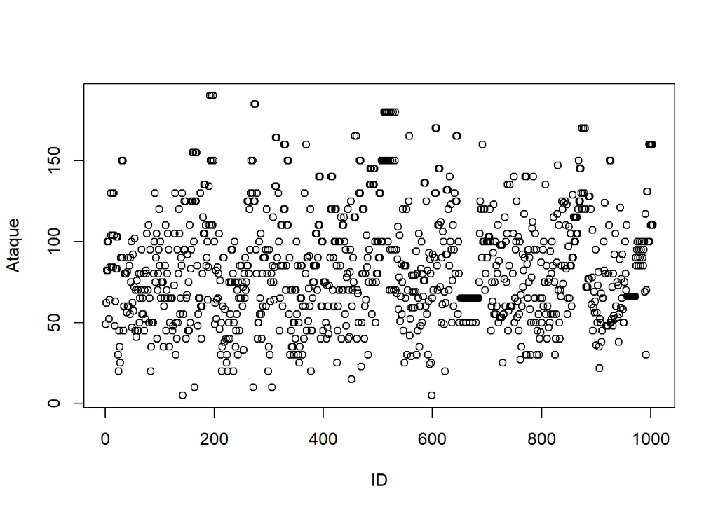

```r
plot(Pokemon$Ataque, type = 'p', ylab = "Ataque", xlab = "ID")
```

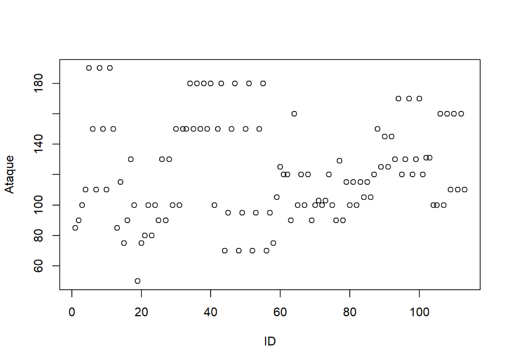

```r
plot(Pokemon$Ataque[which(Pokemon$Lendario == T)], type = 'p', ylab = "Ataque", xlab = "ID")
```

```r
table(Pokemon$Lendario)
```

```
##
## FALSE  TRUE
##   891   113
```

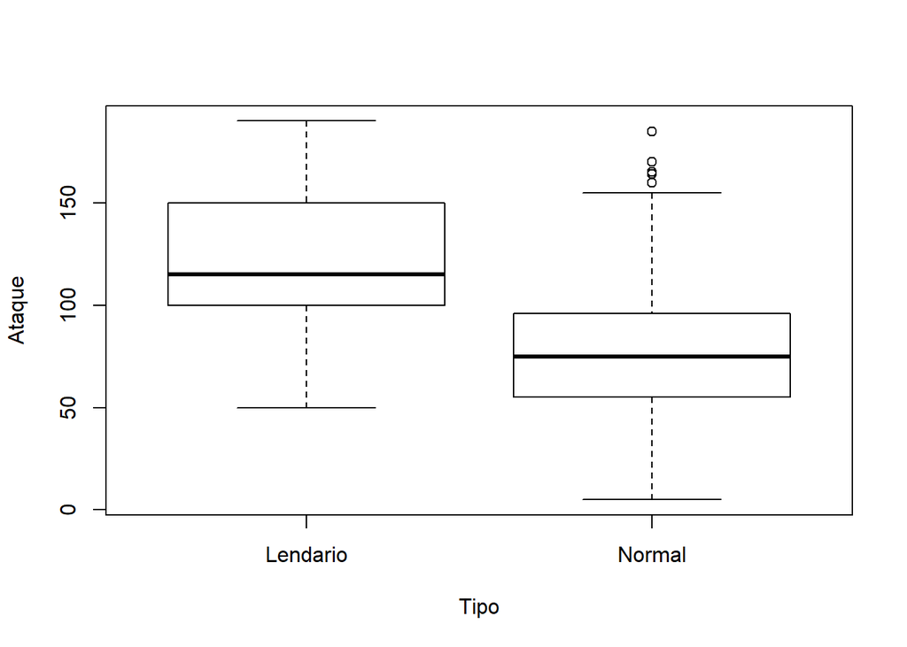

```r
Pokemon$Lendario[Pokemon$Lendario == TRUE] <- "Lendario"
Pokemon$Lendario[Pokemon$Lendario == FALSE] <- "Normal"

boxplot(Pokemon$Ataque ~ Pokemon$Lendario, ylab = "Ataque", xlab = "Tipo")
```

E se quiséssemos usar `ggplot2`?

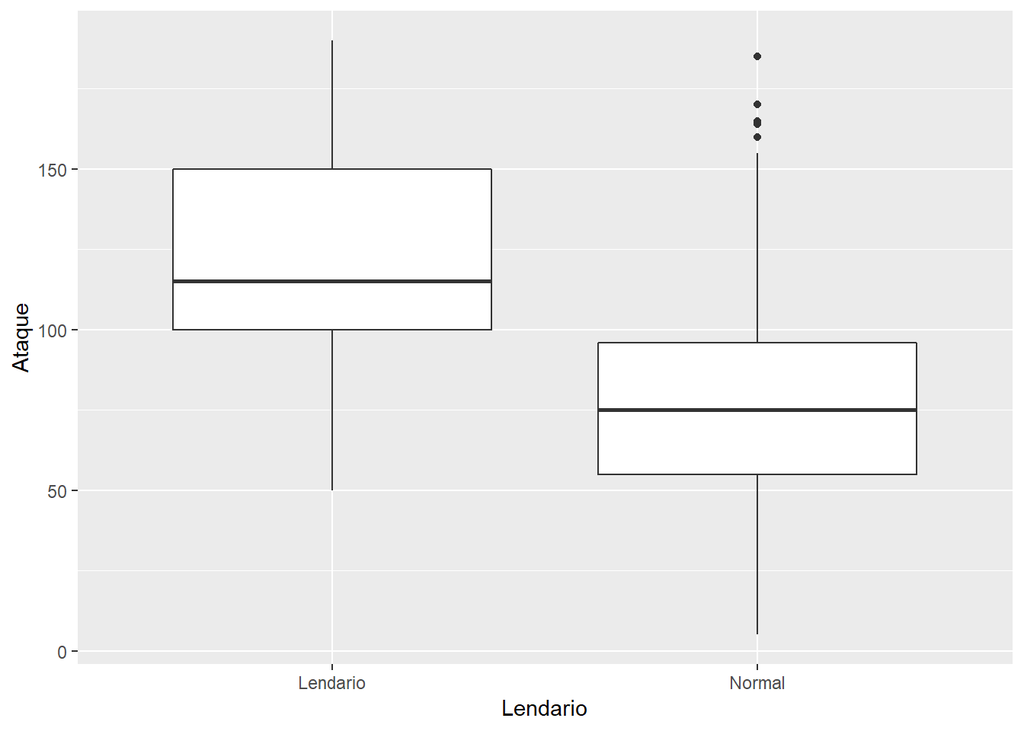

```r
# Descomente a linha abaixo caso você não tenha o ggplot2 instalado
# install.packages("ggplot2")

library(ggplot2)
p <- ggplot(Pokemon, aes(x=Lendario, y=Ataque)) +
  geom_boxplot()
p
```